# Visit Scotland

Juan Ignacio De Vicente Ojeda

2023-01-16

## INTRODUCTION

The aim of this presentation is to show a quick glimpse about the tourist sector between the years 2011 and 2019 in Scotland.Specially the value of visits and the expenditure.

In order to conduct this premise, it had been used the the open data offer by ‘Visit Scotland’ that can be consult in the website of the Scottish Government : ‘statistics.gov.scot’

## Data Context/ Disclaimer/ Assumptions

How is the date? any ethical problem?

Before start, it has to be some considerations.

- Some of the data used presented the variable ‘region of residence’, and observations are ‘All GB’, ‘England’ and ‘Scotland’. Due the fact that GB means England, Scotland and Wales,it has been used the the ‘All GB’ observation because - in our opinion- its the most accurate.
- Also one visitor can realize more than one visits and could lead to a misunderstanding / misinterpretation in the total number of visitors.
- In 2019, Visit Scotland in conjunction with Visit England and Visit Wales change the parameters for recording domestic overnight trips and domestic day trips. It is believed that this new method can produce differents interpretations in visits and expenditure. More info. ‘INSIGHT DEPARTMENT: GBTS 2021 Methodology and Quality’
- Therefore, the intention is to show a glimpse about how was the tourism in the country in 2019 and during previous years. All before the introduction of the new method and the disruption caused by the pandemic and the lockdown restrictions during 2020,2021 and the beginning of 2022 plus the current world economic recession.

## Definitions - Slide

Tourism day trip is defined as:

- Taking part in one of a pre-defined list of activities (based on international tourism definitions)
- Spending 3 or more hours out of the home on this activity
- The activity is not doing “very regularly” by the respondent
- The activity not being carried out in the place that the respondent lives or works
- The exception to this was trips to visitor attractions, live sporting events and special public events, which are all counted as tourism day trips even when in the place of residence, provided they fulfil the other three criteria.To

## Tourism in Scotland. Q1 -Slide Which tourist Activities are survey?

The first Question should be how much money means the domestic tourist activity for Scotland. In this visualization we can see that from 2013 to 2019, the minimum was 2015 and means nearly 4 thousand millions pounds.

## Q1 Value of the tourism for Scotland

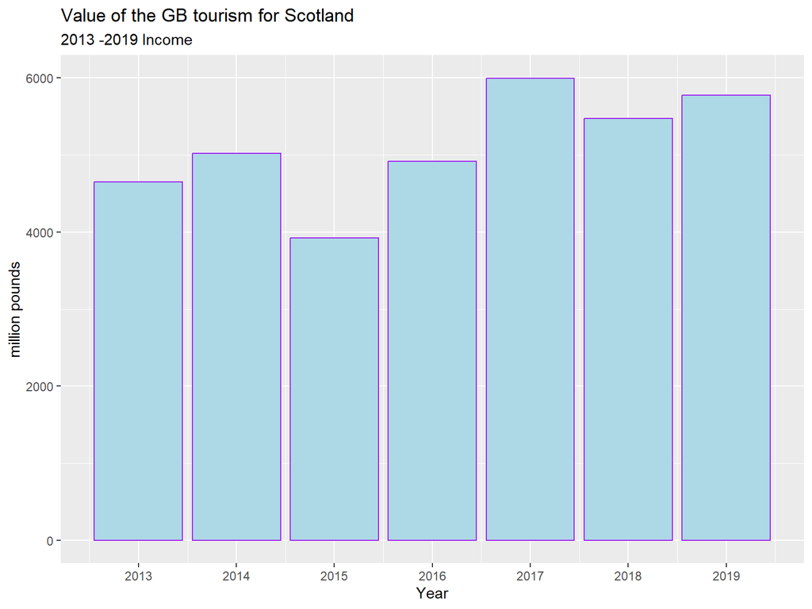

## Q1-Slide 6

Q1. Higest income for Scotland in 2019

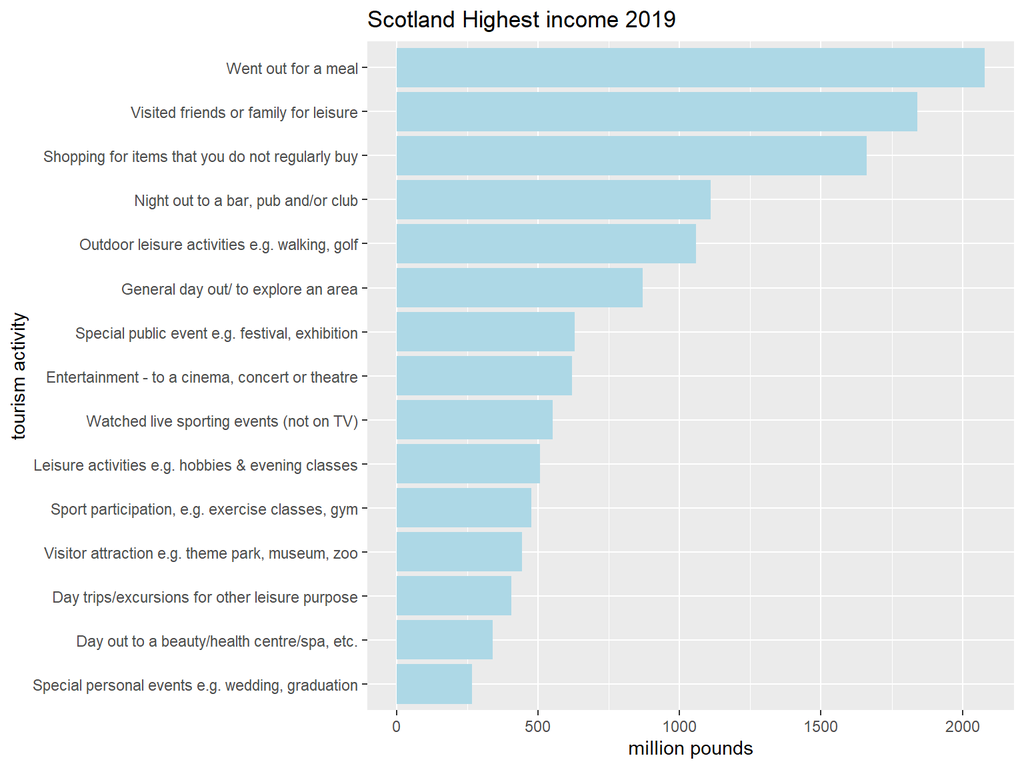

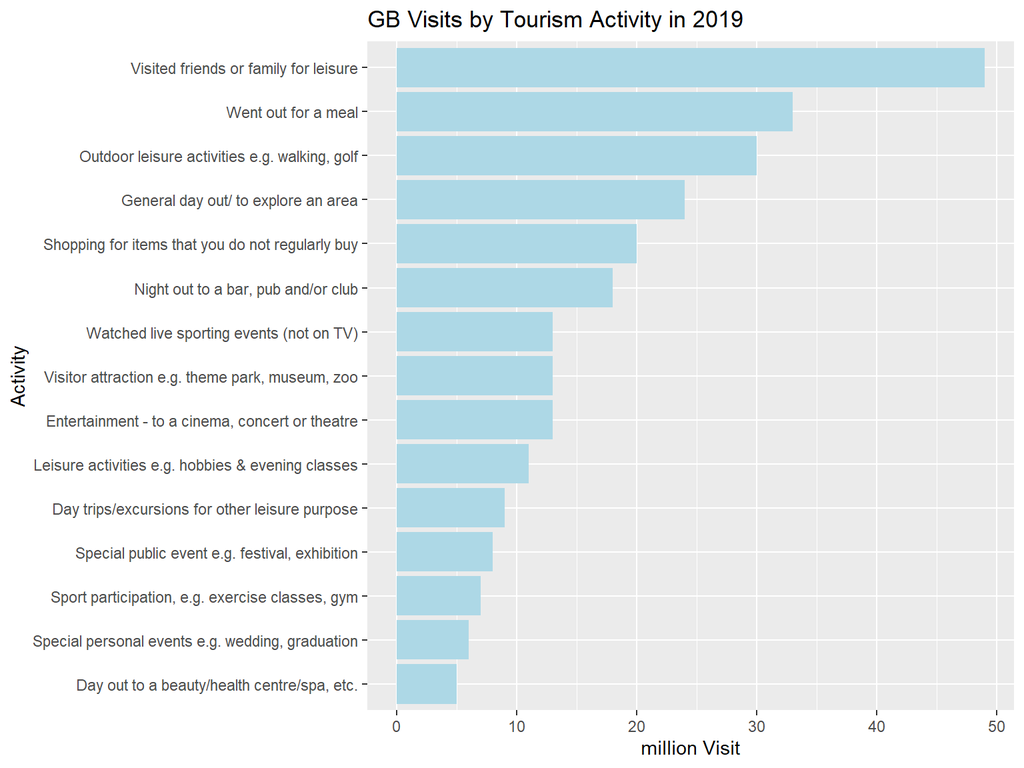

## Q1 Where were these visits in 2019? Location Slide 7

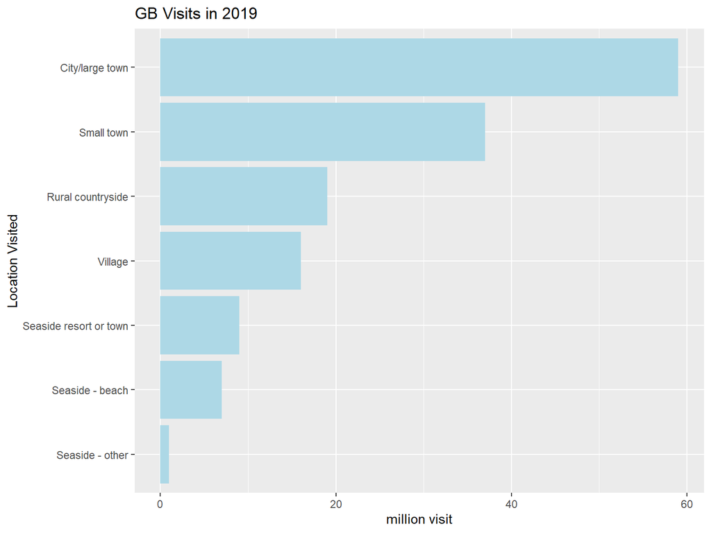

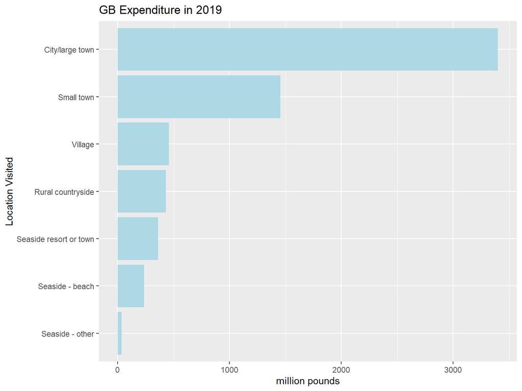

## Here we can see the general tendency. Slide 8

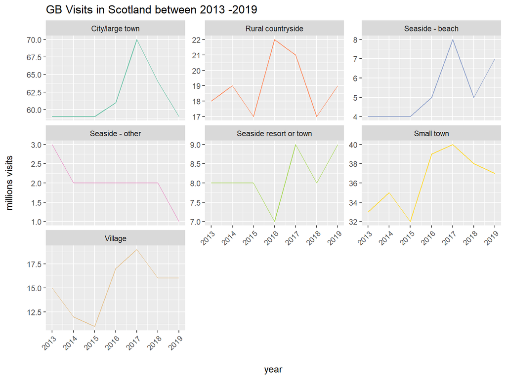

## Slide 9

Althought the tendency is a decrease in visits to large cities , still is mostly the money is spend

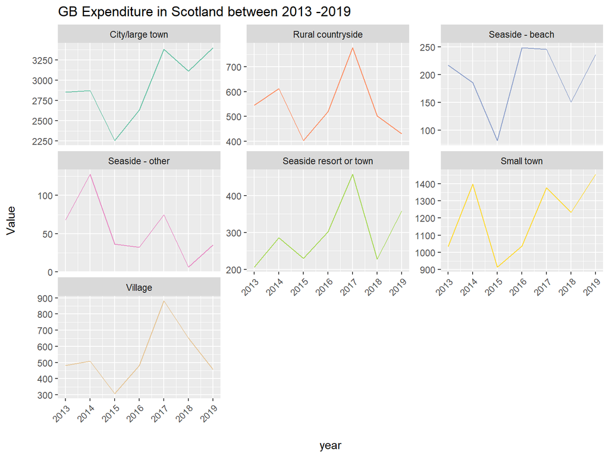

this visualization see the evolution for the period 2013 - 2019 the visits in city/ large town has fallen but the expenditure there has increase in the last year. the Rural countryside shows the opposite the expenditure has decrease but the visits has increase from 2018.

It can be observed that for the year 2019 visits and expenditure are correlated except for the values Village/Rural countryside. In happens as well in the year 2018, 2014

#Q1Slide10 Total visits fromm2013 How was from 2013 to 2019

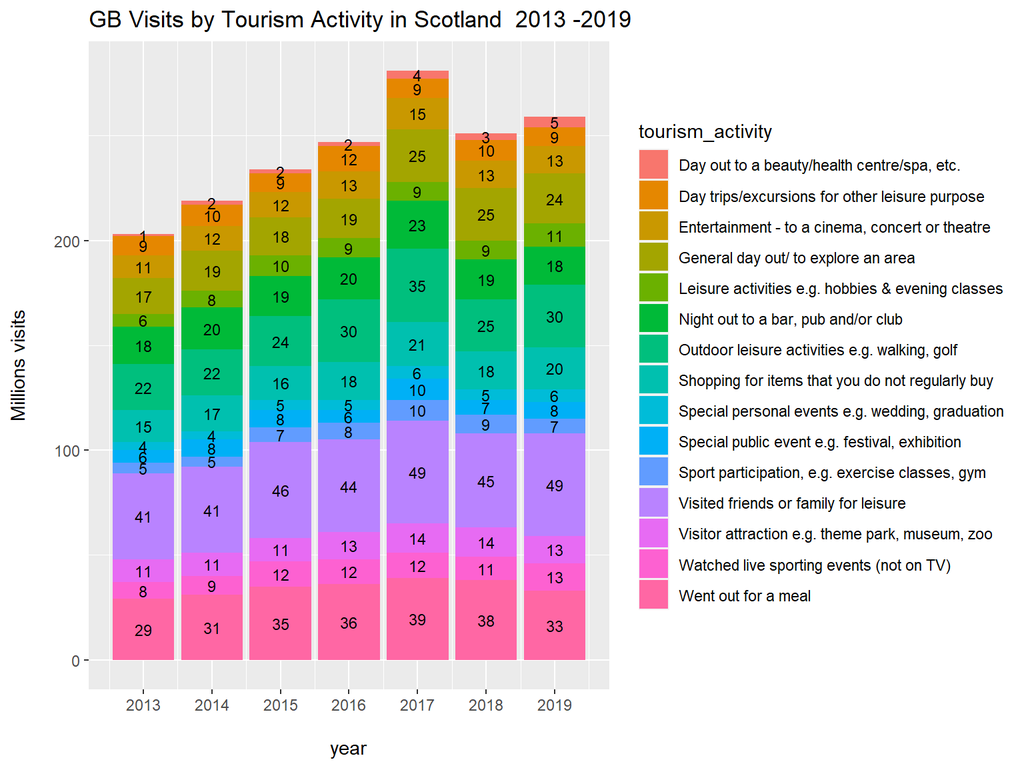

## Demographic Slides

This is general evolution in the tendency of visiting by age

There is not a general tendency each group of age had a prefered year in visit scotland

Millions Visits by age.Time range 2013-2019 More visits people under 24.

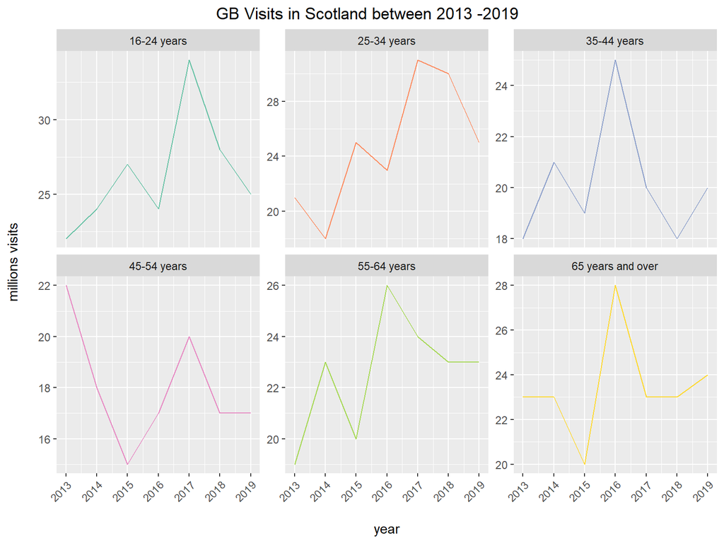

## For the year 2019

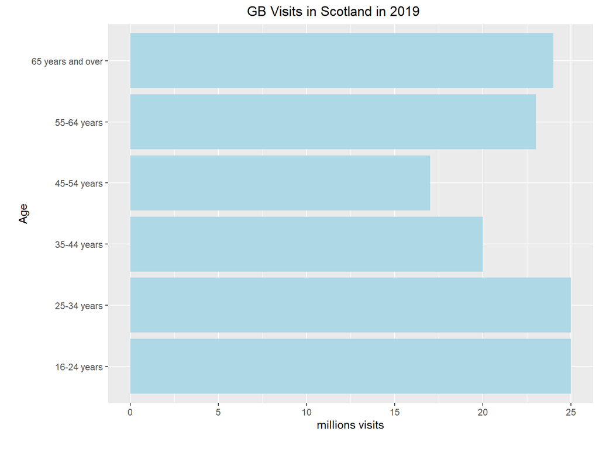

Millions Expenditure by visitors age. More spend people between 25-34 , 55-56 and 35-44.

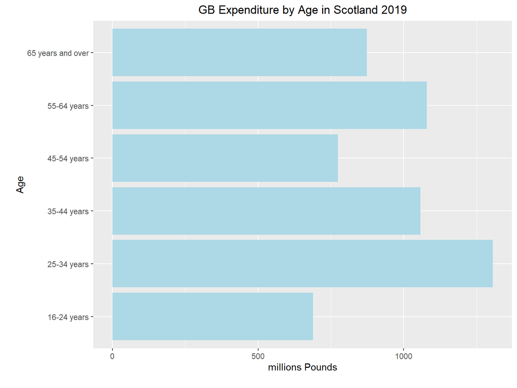

## Gender. More Female than Male in 2019

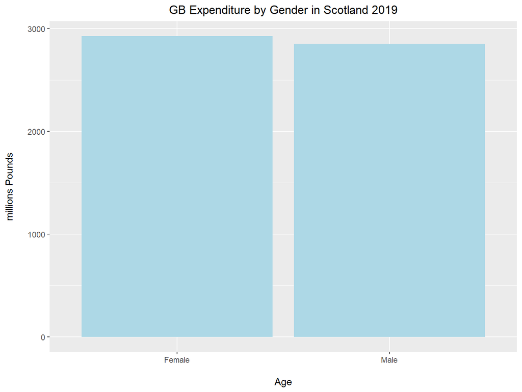

[figure not shown]

## Marital Status

And much more married than not married.

[figure not shown]

*answer* More married than no married

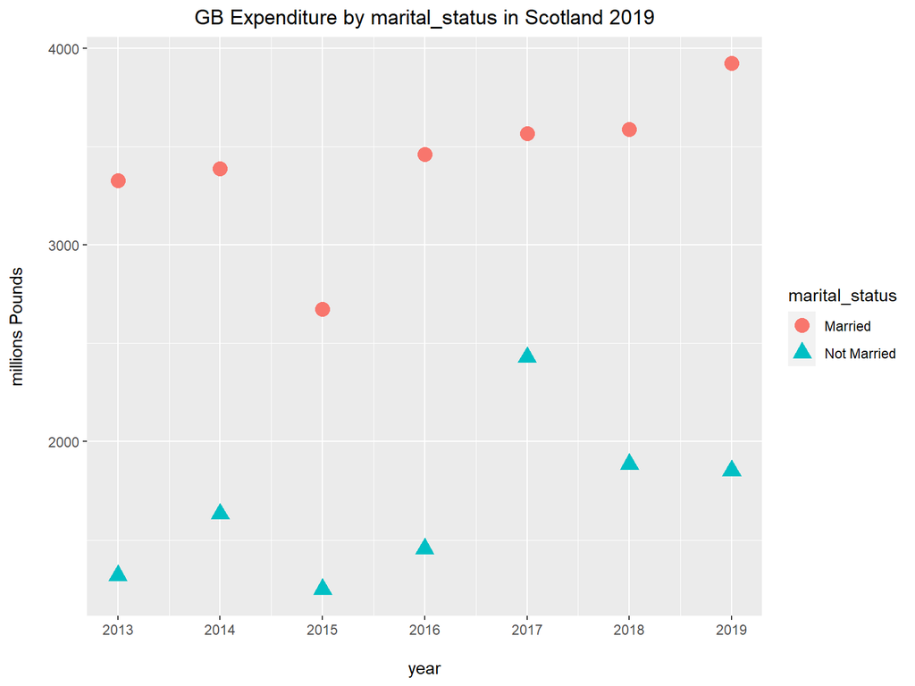

## Childrens? NO! Thanks very interesting!

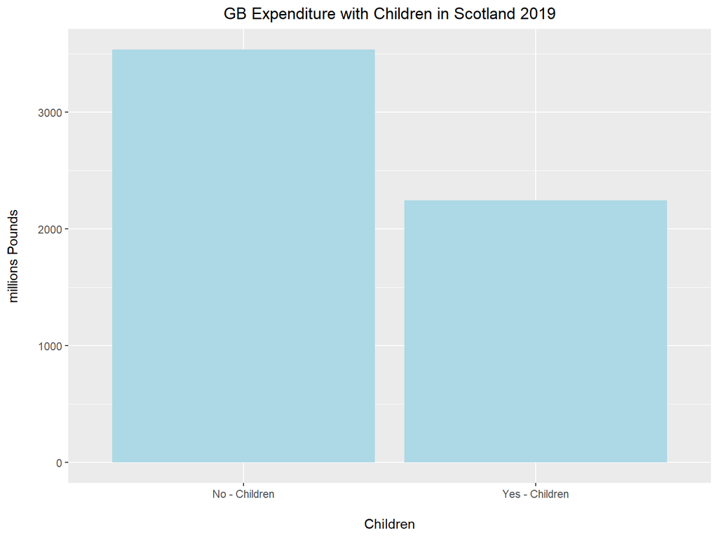

*Answer* Spend more without Kids in 2019

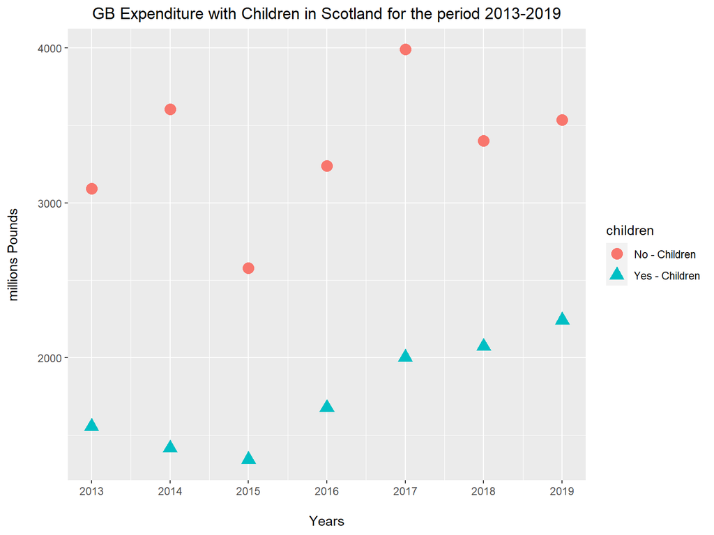

*Answer* Spend more without Kids in all years

## Millions Expenditure by employment_status.

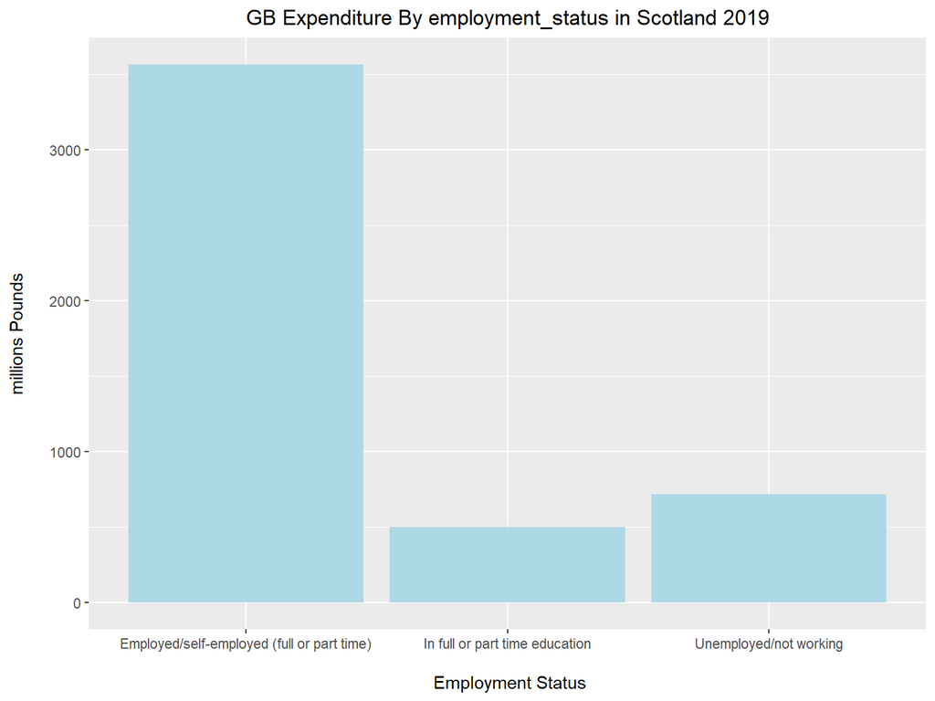

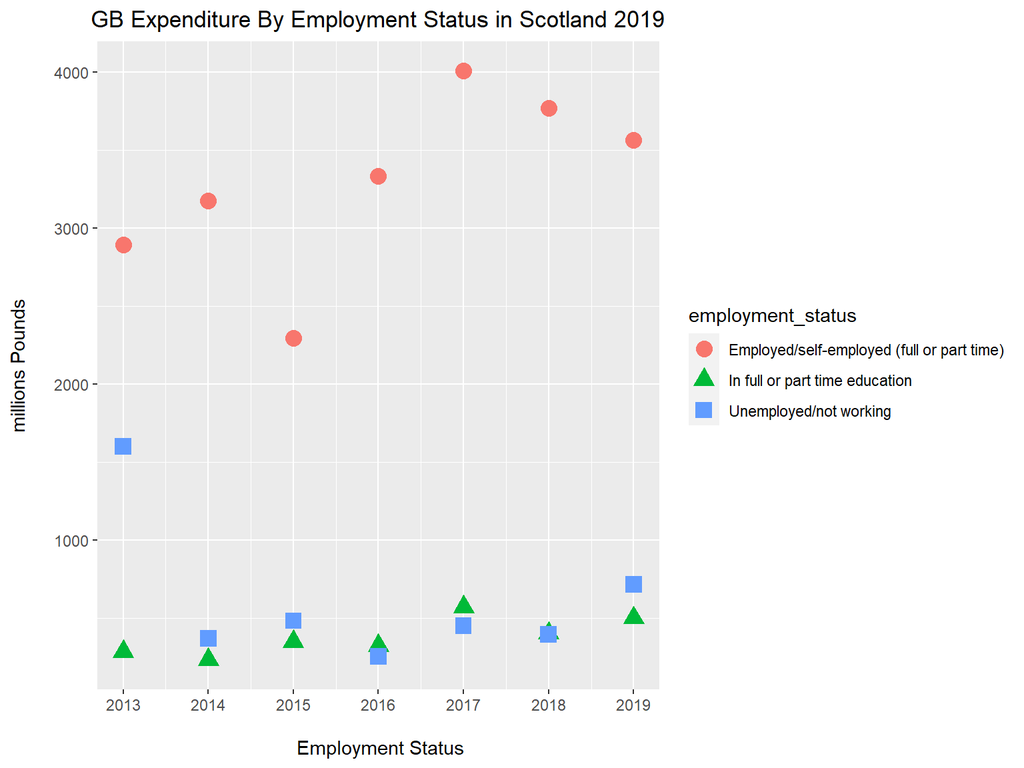

## SocialGrade

Is important the social grade? Is ethical?Funny the most expenditure is the highest grade occupation but the second is in theory the lowest grade occupation ( less money/ less cultured person? assumption)

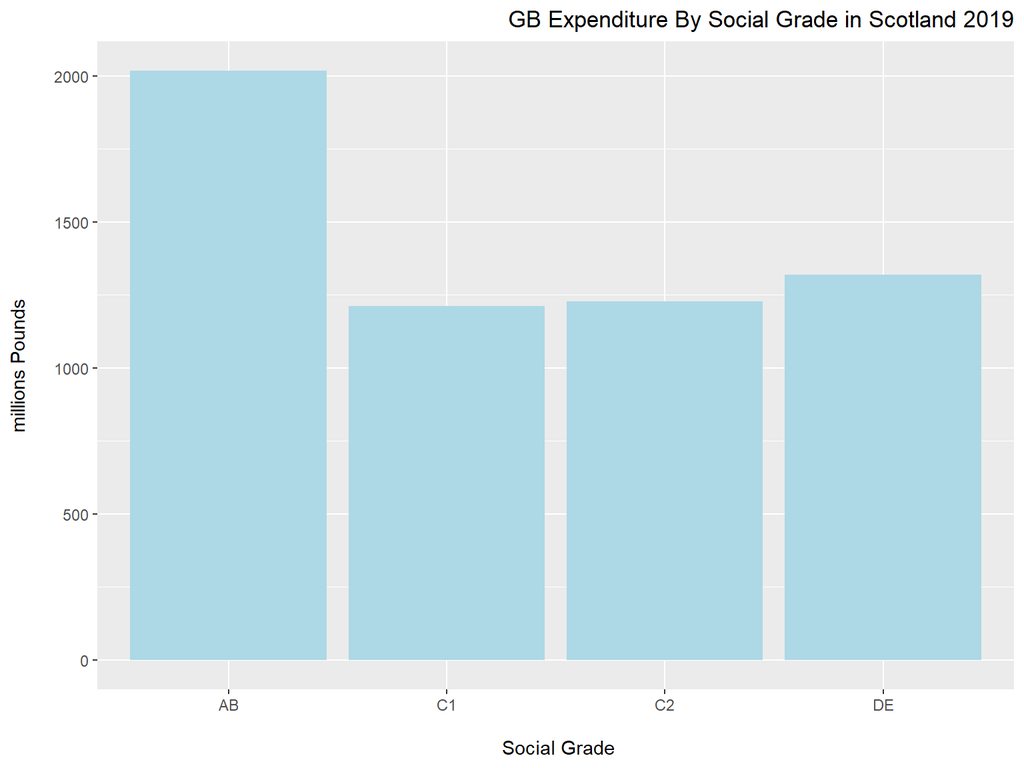

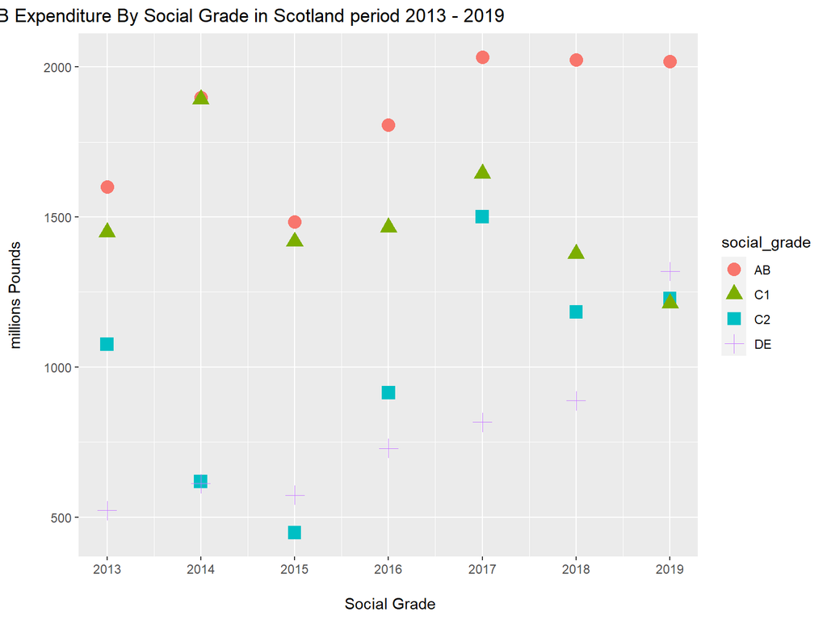

The obvious for social grade but not the last year. Is it ethical? ‘help’ people to spend money

## Transport means where to go, free to travel….

There are few things interesting, 0.5 million visitis arrive by see(boat/ship/ ferry) where is cruise is boat a cruise? ship and ferry can include go to the Islands? only 0.4 take a caravan or campervan but the value of their spend is 24.2 millions of pounds. We can conclude that is minimum visits some Islands such as Mull, Islay, Arran, others such as western Islands , Orkney or Shetlands have airports. Visit the Islands imply more nights and more expenses

En 2019 el transporte por avion solo trajo poco menos de millon y medio de visitas ( 10 puesto) pero a cambio trajo 123 millones de libras(7 puesto). Planes is more to arrive to any airport and later take a hired vehicle , taxi…. so its a way to arrive to scotland more than travel around the country.

How travel people and their expenditure in relation

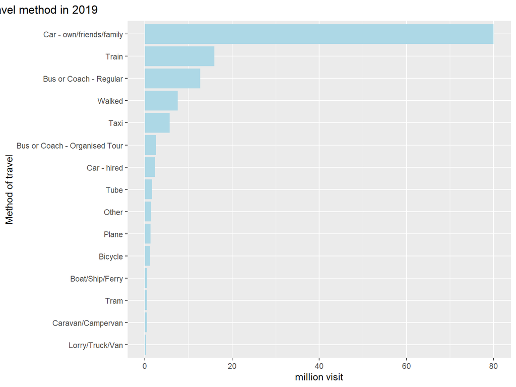

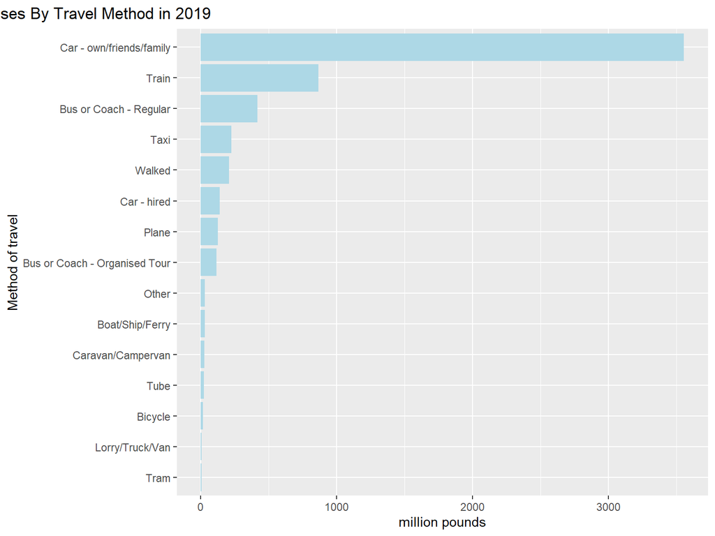

## Where goes the people.

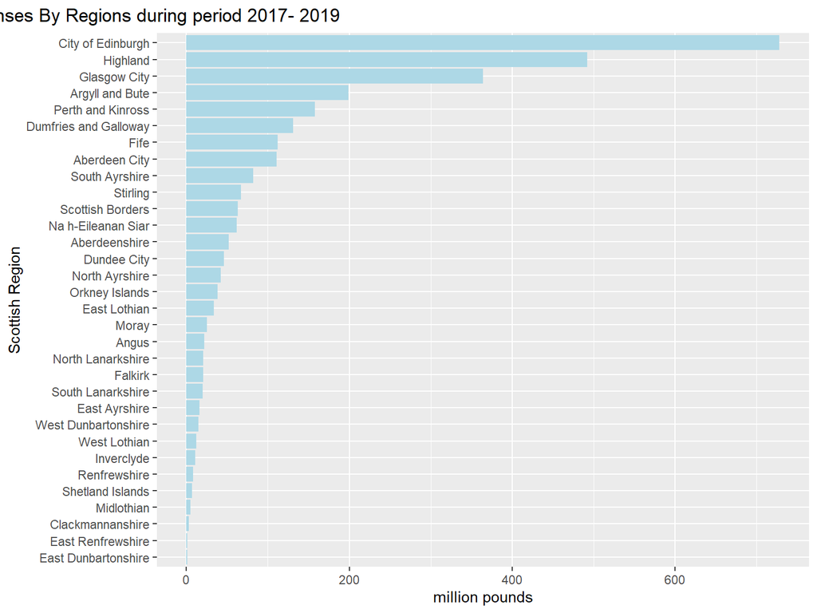

What could we deduce? it is not how to arrive, the Western Islands ( Na h-Elleanan Siar) is over regions of the ‘Central bell’ it is the offer fro activities

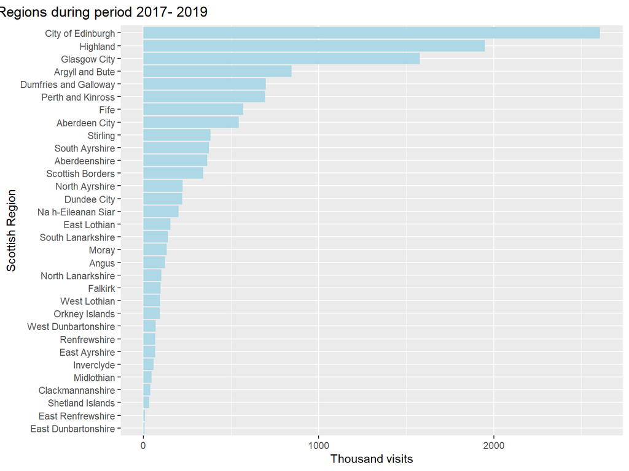

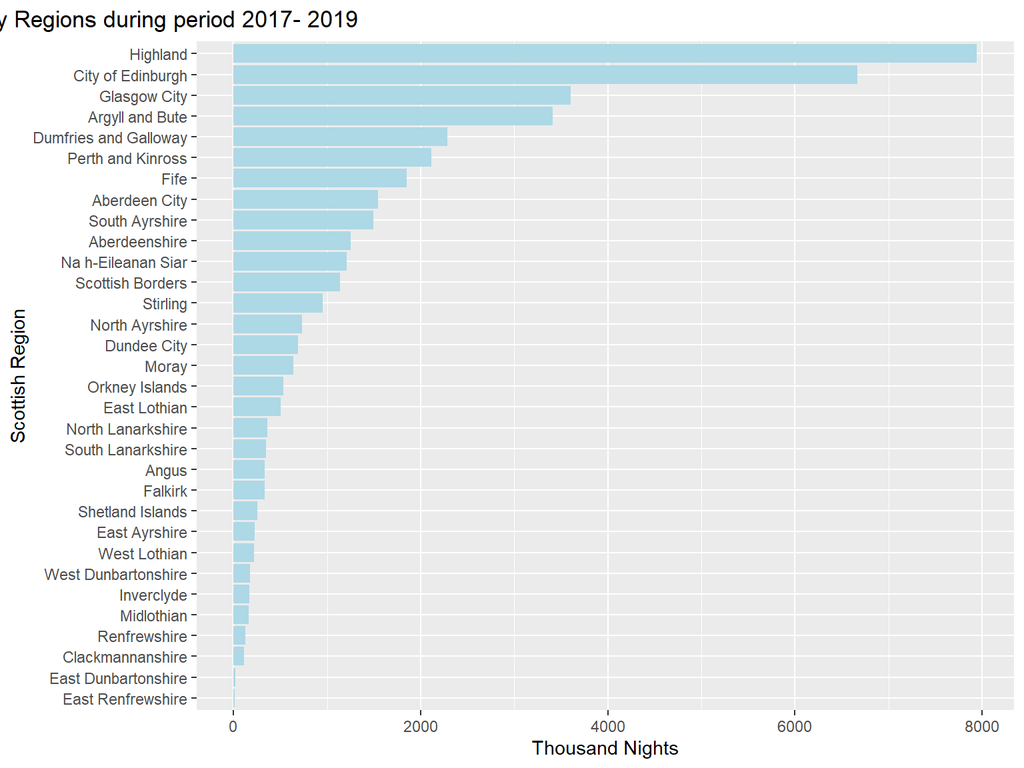

## Accommodation.

Cheap travels for long weekends. Note: difference Room and Bed occupancy, no clear but I understand that Room means the number of occupants per room but Bed means the number of occupants in a room per size bed = 1 single bed and 1 double bed means 3 max occupants. Hotels difference between Rooms and Bed occupancy. Rooms for weekday and beds during weekend. Whats the meaning? Working occupancy plus leisure, a room can have a double bed occupy by one person

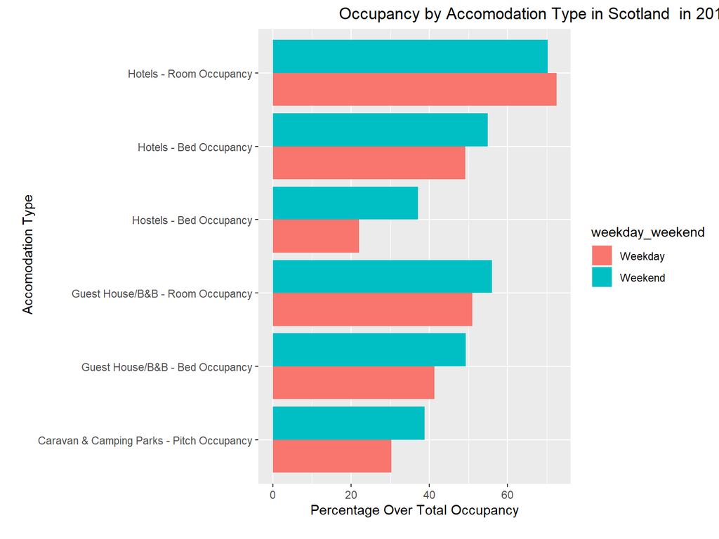

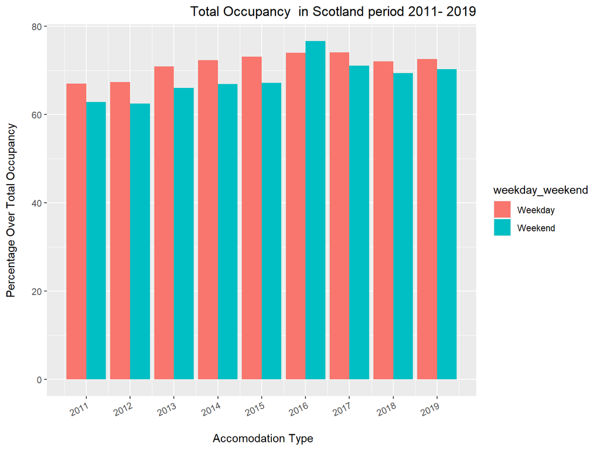

## Occupancy rates

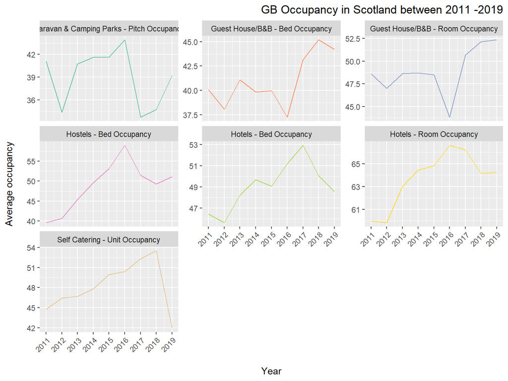

*VISITS/LOCATIONS* In general we see there is a tendency to a slowly fall in the visits for all GB to Scotland. This fact is more clear in ‘urban’ areas or where it could be more visitors.

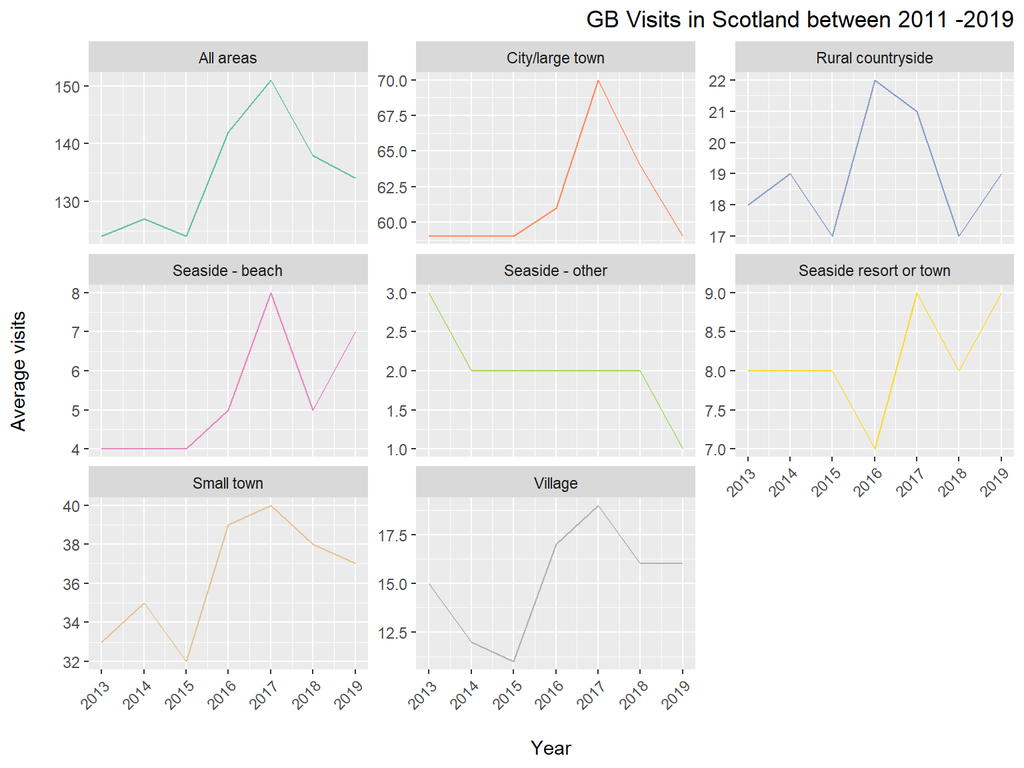

*DEMOGRAPHICS* By age, each year is different, for 2019 the data show that mostly all the age groups falland the only two that grow significantly , 65 or older and 35-44 years old , are under the mark of their beat year that was 2016.

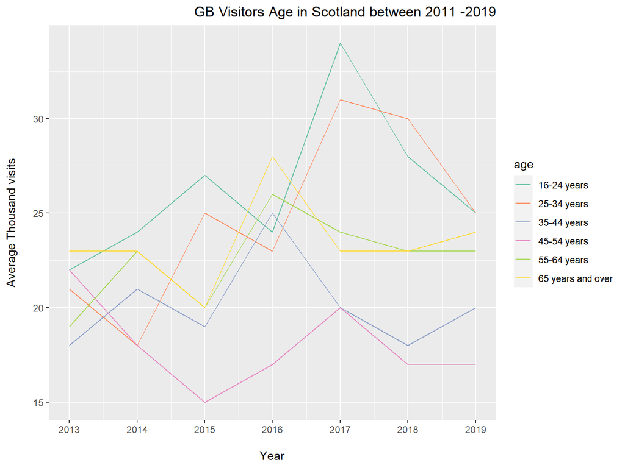

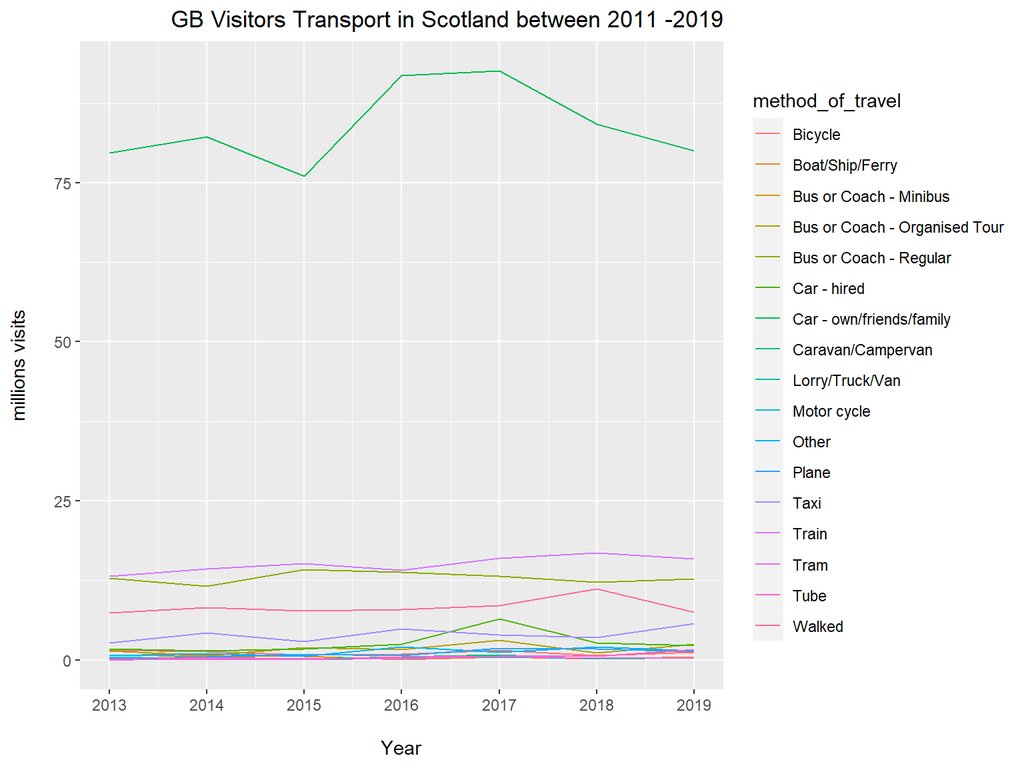